# group3_pair_Durousseau_Forest

# Exercise 1

## question 1

### (a)

```r
dinvgamma <- function(x, alpha, beta){ return(((beta^alpha / gamma(alpha)) * x^(-alpha - 1) * exp(-beta / x)) * (x >= 0)) }
```

### (b)

```r
pinvgamma <- function(x, alpha, beta){ return(ifelse(x > 0, 1 - pgamma(1/x,alpha,rate = beta), 0)) }
```

### (c)

```r
qinvgamma <- function(p, alpha, beta){ return(1 / qgamma(1-p, alpha, rate = beta)) }
```

### (d)

```r
rinvgamma1 <- function(n, alpha, beta){ return(1 / rgamma(n, alpha, rate = beta)) }
```

## question 2

```r
rinvgamma2 <- function(n, alpha, beta){ return(qinvgamma(runif(n, 0, 1), alpha, beta)) }
```

## question 3

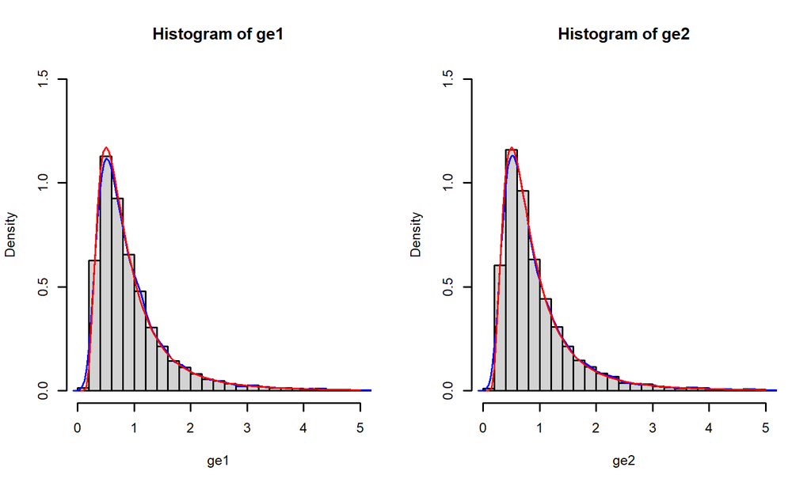

## question 4

```
## Unit: nanoseconds
##  expr min lq mean median uq  max neval
##   ge1   0  0   13      0  0 1300   100
##   ge2   0  0   25      0  0 2500   100
```

```
## [1] "ratio ="          "4.71716847072452"
```

```
##            ge1       ge2
## mean 0.5770322 0.8548094
## var  1.7477666 0.7125227
```

We have that the ratio is over 1, then the best estimator is the one with rinvegamma2(). Moreover, the variance of this estimator is much smaller than the variance of rinvgamma1() meaning that rinvgamma2() is more robuste than rinvgamma1().

# Exercise 2

## question 1

```r
dinvgamma_trunc <- function(x, alpha, beta, b){ return(dinvgamma(x,alpha,beta) * (0 <= x & x <= b)/ (pinvgamma(b,alpha,beta) - pinvgamma(0,alpha,beta)) * (0 <= x & x <= b)) }
```

## question 2

```r
rinvgamma_trunc1 <- function(n, alpha, beta, b){ return(qinvgamma(pinvgamma(0,alpha,beta) + runif(n,0,1) * (pinvgamma(b,alpha,beta) - pinvgamma(0,alpha,beta)),alpha,beta)) }
```

## question 3

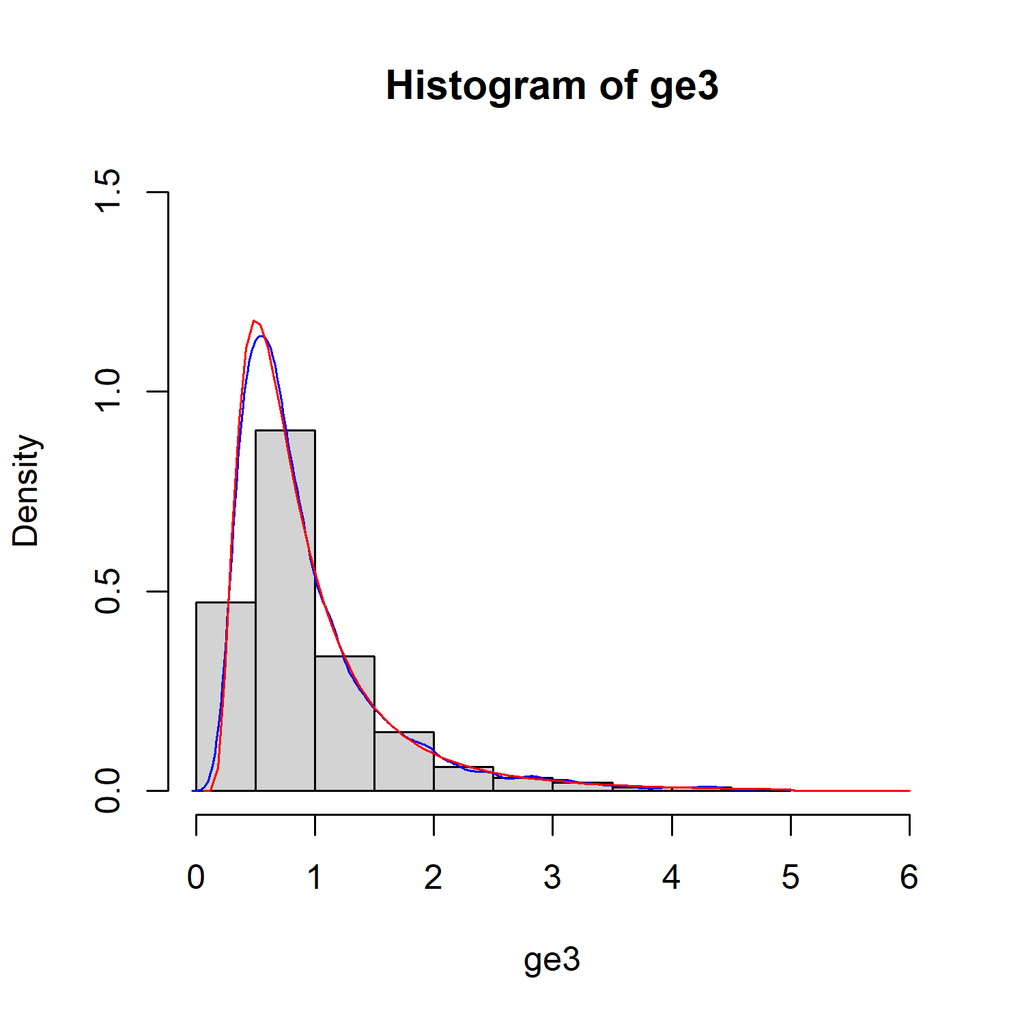

## question 4

### (a)

If $f(x) = f_{\alpha,\beta}(x) \mathbb{1}_{(0,b)}(x)$ and $g(x) = f_{\alpha,\beta}(x)$ . Thus $M = \sup_{x} \frac{f(x)}{g(x)} = b$

### (b)

```r
rinvgamma_trunc2 <- function(n, alpha, beta, b){
  x <- numeric(0)
  f <- function(x,b){ return(dinvgamma(x,alpha,beta) * (x <= b)) }
  while(length(x) < n){
    U <- runif(1)
    X <- rinvgamma1(n, alpha, beta)
    x <- append(x, X[U <= (f(X,b) / (b * dinvgamma(X, alpha, beta)))]) }
  return(x) }
```

### (c)

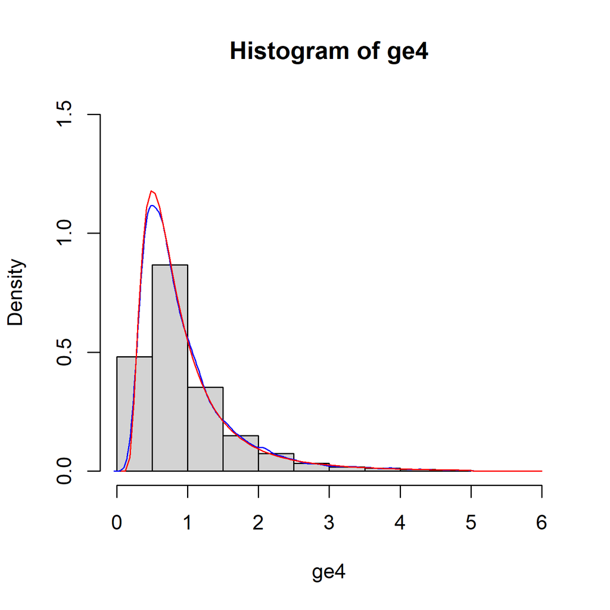

## question 5

### (a)

Here the uniform distribution is of parameters $(0,b)$ as we $x \in (0,b)$

### (b)

we have $f(x) = f_{\alpha,\beta}(x) \mathbb{1}_{(0,b)}(x)$ and $g(x) = \frac{1}{b} \mathbb{1}_{(0,b)}(x)$ . Thus $M = \sup_{x} \frac{f(x)}{g(x)} = b \max_{x} f_{\alpha,\beta} (x) = b f_{\alpha,\beta}(\frac{\beta}{\alpha + 1})$

### (c)

```r
rinvgamma_trunc3 <- function(n, alpha, beta, b){
  x_max <- beta / (alpha + 1)
  M <- b * dinvgamma(x_max,alpha,beta)
  x <- numeric(0)
  f <- function(x,b){ return(dinvgamma(x,alpha,beta) * (x <= b))}
  g <- function(x,b){ return((1/b ) * (0 <= x & x <= b)) }
  while(length(x) < n){
    U <- runif(1)
    X <- runif(1,0,b)
    x <- append(x, X[U <= (f(X,b) / (M * g(X,b)))]) }
  return(x)}
```

### (d)

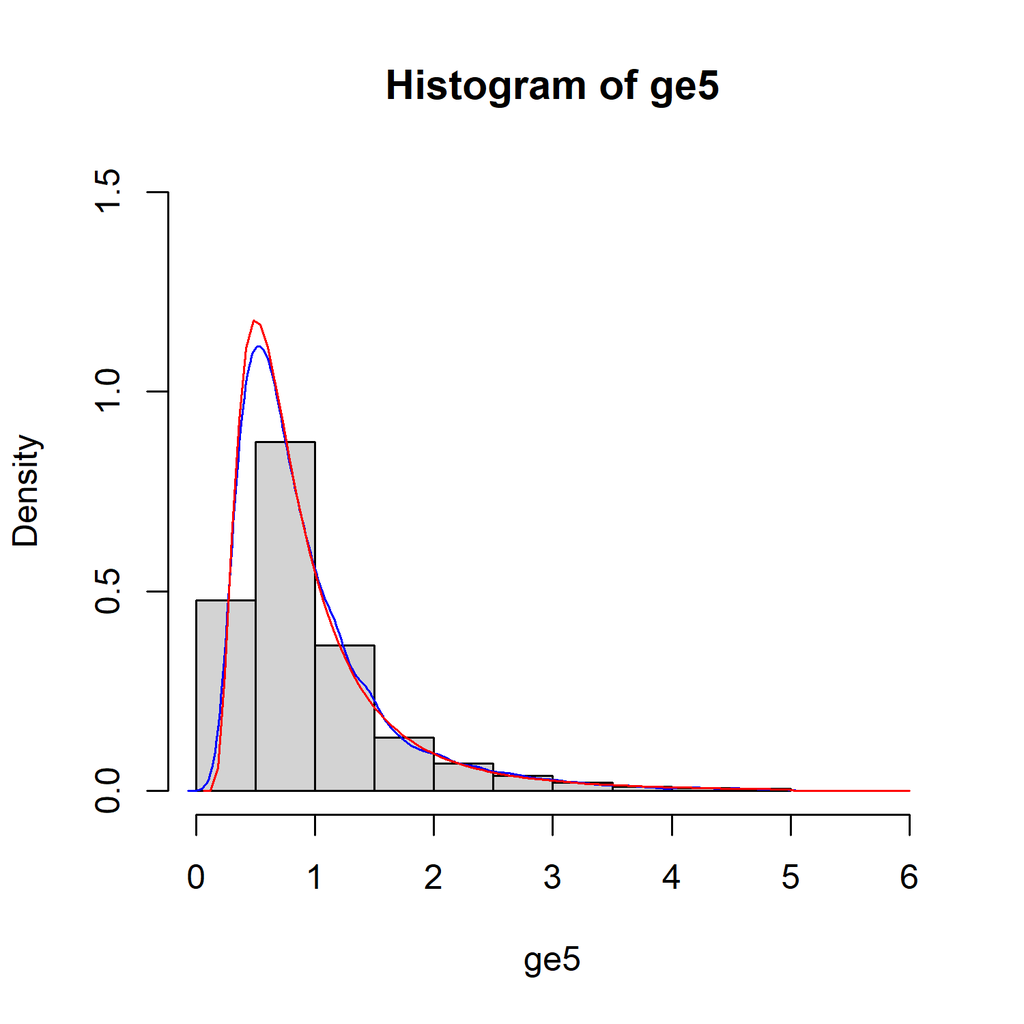

### (e)

```
##             ratio
## b = 5   0.9880651
## b = 0,5        NA
```

```
##          ge4_5     ge5_5      ge4_05      ge5_05
## mean 0.9507669 0.9496996 0.384213047 0.382998668
## var  0.4628637 0.4684547 0.005918165 0.006023472
```

# Exercise 3

## question 1

```r
estim_mc_invgamma <- function(n, sample_y, alpha, beta, b){
  hs <-  (1 - sample_y^2) * as.numeric(sample_y <= b)
  return(c(mean(hs), var(hs)))}
```

## question 2

```r
estim_mc_invgamma_trunc <- function(n, sample_y, alpha, beta){
  hs <- 1 - sample_y^2
  return(c(mean(hs), var(hs)))}
```

## question 3

```
##            mc_1       mc_2 mc_trunc_1 mc_trunc_2 mc_trunc_3
## mean -0.3845666 -0.3366639 -0.3441985 -0.3351464 -0.3468401
## var   6.2751583  6.1208799  5.9226983  5.8398258  5.6738290
```

```
## Unit: nanoseconds
##        expr min lq mean median uq  max neval
##        mc_1   0  0    9      0  0  900   100
##        mc_2   0  0   24      0  0 2400   100
##  mc_trunc_1   0  0    6      0  0  600   100
##  mc_trunc_2   0  0    9      0  0  900   100
##  mc_trunc_3   0  0    3      0  0  300   100
```

```
##                mc_1 mc_2 mc_trunc_1 mc_trunc_2
## mc_2            Inf   NA         NA         NA
## mc_trunc_1 2.825360    0         NA         NA
## mc_trunc_2 8.596364    0   3.042573         NA
## mc_trunc_3      Inf  NaN        Inf        Inf
```

We can see that the better estimator is mc_trunc_2() the Monte-Carlo estimator base on a $InvGamma_{[0,b]}(\alpha,\beta)$ or mc_trunc_3() the Monte-Carlo estimator base on a $\mathcal{U}([0,b])$ depending on the randomness of the microbenchmark function. This estimator has the smallest variance with a ratio with the other estimator always letting us choose it (greater or equal than 1).

```
##           mc_1      mc_2  mc_trunc_1 mc_trunc_2  mc_trunc_3
## mean 0.2003620 0.2028876 0.846194880 0.84621433 0.844899830
## var  0.1304341 0.1315589 0.003245294 0.00322099 0.003220817
```

```
## Unit: nanoseconds
##        expr min lq mean median uq  max neval
##        mc_1   0  0   40      0  0 3100   100
##        mc_2   0  0   15      0  0  500   100
##  mc_trunc_1   0  0    9      0  0  500   100
##  mc_trunc_2   0  0   25      0  0 1100   100
##  mc_trunc_3   0  0   21      0  0  400   100
```

Here the variance of our estimator are so close to 0 that the ratio will not be relevant, as we divide something really close to 0 by something really close to 0 it’s undetermined. But we can argue with the matrix displaying all the mean-var that the best estimator is also mc_trunc_2() or mc_trunc_3() with the same argument as previously.